# Analysis of ERK dynamics in response to EGF/NGF/FGF2 stimulations

Maciej Dobrzyński

September 15, 2019

This is an R notebook accompanying the [workshop](https://quantbio2019.epfl.ch) *QUANTITATIVE BIOLOGY: BRIDGING THE GAP BETWEEN COMPUTATIONAL AND EXPERIMENTAL APPROACHES (EPFL – ETHZ SUMMER SCHOOL 2019) QUANTBIO2019*.

In this analysis we will use following R packages:

```r
# load packages

require(data.table, quietly = T)  # for fast processing of large datasets
require(readxl, quietly = T)      # to read Excel files
require(R.utils, quietly = T)     # to read compressed files directly without unzipping
require(imputeTS, quietly = T)    # for data imputation
require(ggplot2, quietly = T)     # to make amazing plots
require(plotly, quietly = T)      # to make the amazing plots interactive
```

Set some global variables with parameters of the analysis:

```r
# set some global variables

lPar = list(
  dirRoot = ".",
  dirData = "data",
  freqAcq = 2 # acquisition frequency in minutes

)
```

# Data description

Data come from a microfluidic experiment where PC-12 cells were stimulated with 3 different growth factors (EGF, NGF, FGF2) at different concentrations. It is part of a study *Temporal perturbation of Erk dynamics reveals network architecture of FGF2-MAPK signaling*, (2019) available [here](https://doi.org/10.1101/629287).

The microfluidic device has four separate channels, thus 4 different tretaments can be performed in a single experiment.

The PC-12 cells express a FRET biosensor to indicate activity of the ERK kinase, an end point of the MAPK singnalling pathway. Three different growth factors tested activate different parts of the MAPK network and result in different signalling dynamics, i.e. the behavior of ERK activity over time.

Cells stimulated with growth factors were then imaged with a single-cell resolution over 3-4 hours at a 2-minute time resolution. Each channel of a microfluidic device was imaged at 4 different fields of view. Thus, we have 16 fields of view per experiment.

The folder `data` contains 3 sets of files that correspond to 3 growth factor treatments at 4 different concentrations. A single set from a single experiment includes:

`tCoursesSelected_xGFsust_expXXXX.csv.gz` a compressed file with single-cell data. Each row corresponds to the measurement of ERK activity in a single cell, at a single time point. Columns:

- `Metadata_Series` an integer, 0-15, that corresponds to the field of view.
- `Metadata_T` an integer, 0-100, corresponds to the time frame number in a movie from a single field of view.
- `TrackObjects_Label` an integer that describes the track number from object tracking algorithm. The number is unique inly within a single field of view.
- `Intensity_MeanIntensity_Ratio` a float with the measurement of FRET ratio; this is our proxy of ERK activity.

`experimentDescription_EGFsust.xlsx` an Excel file with experiment description. Columns:

- `Position` an integer, 0-15, with the number of the field of view.
- `Channel` an integer, 1-4, with the number of the microfluidic channel.
- `Stim_Conc` a string with an indication of the GF ocncentration.

# Load data

The aim is to load 3 files that correspond to 3 GF treatments and to combine them into a single `data.table` object that includes info about the experiment.

## Brute-force way

Since we only have 3 files we can just load data as 3 separate variable and concatenate them later.

```r
# Load individual files
dtEGF = fread(file.path(lPar$dirRoot, lPar$dirData, "original/tCoursesSelected_EGFsust_exp20170316.csv.gz"))
dtFGF = fread(file.path(lPar$dirRoot, lPar$dirData, "original/tCoursesSelected_FGFsust_exp20170224.csv.gz"))
dtNGF = fread(file.path(lPar$dirRoot, lPar$dirData, "original/tCoursesSelected_NGFsust_exp20170725.csv.gz"))
```

A quick peek into one of the tables reveals the content. There is no info about the experiment, nor the treatment.

```r
head(dtEGF)
```

[output not shown]

All experimental data is in sepearate Excel files that we have to read as well.

```r
dtEGFexp = as.data.table(read_xlsx(file.path(lPar$dirRoot, lPar$dirData, "original/experimentDescription_EGFsust.xlsx")))
dtFGFexp = as.data.table(read_xlsx(file.path(lPar$dirRoot, lPar$dirData, "original/experimentDescription_FGFsust.xlsx")))
dtNGFexp = as.data.table(read_xlsx(file.path(lPar$dirRoot, lPar$dirData, "original/experimentDescription_NGFsust.xlsx")))

head(dtEGFexp)
```

We have to merge experimental data with experiment description. The single-cell data stored in `dtXGF` contains only information about the field of view in a column `Metadata_Series`. Experimental data in `dtXGFexp` contains the information about the treatment for every field of view from the `Position` column. The merge operation will assign experiemntal description for every row in `dtXGF` by matching the field of view. As a result, the `dtXGF` will be expanded with additional columns with a description of the treatment.

**Note:** we will use only some columns from the experimental description.

```r
# columns tha we want from experimental description files
vsExpDescrCols = c("Position", "Channel", "Stim_Conc", "Stim_Treat")

# merge data
dtEGF = merge(dtEGF, dtEGFexp[, ..vsExpDescrCols], by.x = c("Metadata_Series"), by.y = "Position")
dtFGF = merge(dtFGF, dtFGFexp[, ..vsExpDescrCols], by.x = c("Metadata_Series"), by.y = "Position")
dtNGF = merge(dtNGF, dtNGFexp[, ..vsExpDescrCols], by.x = c("Metadata_Series"), by.y = "Position")

head(dtEGF)
```

Now, with 3 experimental results loaded and merged with experimental data, we can make a single data object. We will just “put” one dataset after another in a row-bind operation using `rbindlist` function.

```r
# let's make a list of our data tables
lData = list(EGF = dtEGF, FGF = dtFGF, NGF = dtNGF)

# clean unnecessary objects
rm(dtEGF, dtFGF, dtNGF)
rm(dtEGFexp, dtFGFexp, dtNGFexp)

# let's bind it:
dtAll = rbindlist(lData)
```

*Side note*: since we created a **named** list `lData` with 3 data tables, we can now access list elements by reference instead of an index, e.g.:

```r
head(lData[["NGF"]])
```

```r
# extract column names from every dt in a list
lColNames = lapply(lData, names)

lColNames
```

[output not shown]

Seems like `dtFGF` contains additional two columns. Let’s select column names that are common in all 3 data tables. We will use a function `intersect` that looks for common elements of two vectors. Since we need to find common elements in all 3 vectors with column names, we will use `Reduce` function that applies `intersect` to consecutive pairs from the `lColNames` list, i.e. 1-2, (the result of 1-2)-3, etc.

```r
vsCommonColNames = Reduce(intersect, lColNames)
vsCommonColNames
```

Let’s try row-bidning again but with an option `fill=TRUE` which fills NAs in columns that are not present. Then we will choose only common columns from each `dt`:

```r
# row-bind
dtAll = rbindlist(lData, fill = T, idcol = "Stim_Treat")

# choose only relevant columns
dtAll = dtAll[, ..vsCommonColNames]

# remove unnecessary objects
rm(lData, lColNames, vsCommonColNames)

head(dtAll)
```

## Read files in a loop (advanced)

This is a much more convenient way to batch read a large number of files.

```r
# create a list of files to read by searching a folder for files according to a pattern
vsInputFiles = list.files(path = file.path(lPar$dirRoot, lPar$dirData, "original"),
                          pattern = "*.csv",
                          full.names = T)

# apply a file-reading function to the list of file names
lData = lapply(vsInputFiles, fread)
```

Each element of the list `lData` contain a `data.table`. There are 3 elements that correspond to the 3 files. It is handy to add an information which file the data came from. It will be useful later on to differentiate data between conditions. One way to achieve that is to give list elements a name. The name will be the growth factor name extracted from the file name using a `gsub` function and [regular expressions](https://www.cheatography.com/davechild/cheat-sheets/regular-expressions/).

```r
# assign names to list elements; extract growth factor name from the file path
names(lData) = gsub(".*_(.*)sust_.*", "\\1", vsInputFiles)

names(lData)
```

```
[1] "EGF" "FGF" "NGF"
```

Now, we are in a position to bind all list elements into a single `data.table`:

```r
# combine data into a single object; the option idcol adds a column that corresponds to the name of the element list
dtAll = rbindlist(lData, use.names = T, idcol = "Stim_Treat")
```

```
Error in rbindlist(lData, use.names = T, idcol = "Stim_Treat") :
  Item 2 has 6 columns, inconsistent with item 1 which has 4 columns. To fill missing columns use fill=TRUE.
```

We have a problem because data tables do not have the same number of columns:

```r
lapply(lData, names)
```

```
$EGF
[1] "Metadata_Series"               "Metadata_T"                    "TrackObjects_Label"            "Intensity_MeanIntensity_Ratio"

$FGF
[1] "Metadata_Series"               "Metadata_T"                    "TrackObjects_Label"            "Intensity_MeanIntensity_Ratio"
[5] "Location_Center_X"             "Location_Center_Y"

$NGF
[1] "Metadata_Series"               "Metadata_T"                    "TrackObjects_Label"            "Intensity_MeanIntensity_Ratio"
```

FGF data has additional 2 columns. We can use `fill = T` option to `rbindlist` which will fill columns that do no exist with NA’s. The we will choose only those columns that existed in all list elements.

```r
# create a vector with common column names that exist in all list elements
vsCommonColNames = Reduce(intersect, lapply(lData, names))

# combine data into a single object; the option idcol adds a column that corresponds to the name of the element list
dtAll = rbindlist(lData, use.names = T, fill = T, idcol = "Stim_Treat")

# add the new column name Stim_Treat
vsCommonColNames = c(vsCommonColNames, "Stim_Treat")

# retain anly some column names
dtAll = dtAll[, ..vsCommonColNames, with = F]

head(dtAll)
```

| Metadata_Series | Metadata_T | TrackObjects_Label | Intensity_MeanIntensity_Ratio | Stim_Treat |
| --- | --- | --- | --- | --- |
| 0 | 0 | 3 | 1229.246 | EGF |
| 0 | 0 | 4 | 1279.513 | EGF |
| 0 | 0 | 8 | 1236.920 | EGF |
| 0 | 0 | 12 | 1170.460 | EGF |
| 0 | 0 | 13 | 1150.294 | EGF |
| 0 | 0 | 15 | 1128.049 | EGF |

Finally, we need to add experimental data:

```r
# create a list of files to read by searching a folder for files according to a pattern
vsExpFiles = list.files(path = file.path(lPar$dirRoot, lPar$dirData, "original"),
                          pattern = "*.xlsx",
                          full.names = T)

# apply a file-reading function to the list of file names
lExp = lapply(vsExpFiles, read_xlsx)

# bind list elements into a single `data.table` object
dtExp = as.data.table(rbindlist(lExp))
```

The merge of single-cell data with experimental description is done by treatment (`Stim_Treat`) and field of view (`Position` / `Metadata_Series` columns). We will use only some cilumns from `dtExp`.

```r
vsExpDescrCols = c("Position", "Channel", "Stim_Conc", "Stim_Treat")

dtAll = merge(dtAll, dtExp[, ..vsExpDescrCols], by.x = c("Stim_Treat", "Metadata_Series"), by.y = c("Stim_Treat", "Position"))

# remove unnecessary objects
rm(lData, lExp, dtExp, vsExpDescrCols, vsInputFiles, vsExpFiles, vsCommonColNames)

dtAll
```

| Stim_Treat | Metadata_Series | Metadata_T | TrackObjects_Label | Intensity_MeanIntensity_Ratio | Channel | Stim_Conc |
| --- | --- | --- | --- | --- | --- | --- |
| EGF | 0 | 0 | 3 | 1229.246 | 1 | 250 ng/ml |
| EGF | 0 | 0 | 4 | 1279.513 | 1 | 250 ng/ml |
| EGF | 0 | 0 | 8 | 1236.920 | 1 | 250 ng/ml |
| EGF | 0 | 0 | 12 | 1170.460 | 1 | 250 ng/ml |
| EGF | 0 | 0 | 13 | 1150.294 | 1 | 250 ng/ml |
| EGF | 0 | 0 | 15 | 1128.049 | 1 | 250 ng/ml |
| EGF | 0 | 0 | 21 | 1180.032 | 1 | 250 ng/ml |
| EGF | 0 | 0 | 22 | 1206.051 | 1 | 250 ng/ml |
| EGF | 0 | 0 | 27 | 1178.254 | 1 | 250 ng/ml |
| EGF | 0 | 0 | 29 | 1263.069 | 1 | 250 ng/ml |

[output cut: 990 more lines]

# Milestone 1

Let’s save the resulting data as a milestone for future reference:

```r
sFilePathTmp = file.path(lPar$dirRoot, lPar$dirData, "m1_allGF_wExpDescr.csv")

fwrite(x = dtAll, file = sFilePathTmp, row.names = F)

# Compress the file to save space
gzip(sFilePathTmp, overwrite = T)

rm(sFilePathTmp)
```

If your are completely lost, here’s a file with the dataset resulting from previous steps:

```r
dtAll = fread(file.path(lPar$dirRoot, lPar$dirData, "m1_allGF_wExpDescr.csv.gz"))
```

# Column names

So far, we have hard-coded column names in multiple points throughout the script, which is a **very bad practice**! Column names can change, which would then require multiple changes in the code. Let’s at least store the names of all columns in one place and make the code more robust.

```r
# create a list with strings for column names

lCol = list(
  fov = "Metadata_Series",
  frame = "Metadata_T",
  trackid = "TrackObjects_Label",
  meas = "Intensity_MeanIntensity_Ratio",
  ch = "Channel",
  treatGF = "Stim_Treat",
  treatConc = "Stim_Conc",
  trackiduni = "TrackObjects_Label_Uni" # we will add this column later to our data
)
```

If required, column names can be changed only here and the remianing code can be left intact. Alternatively, column name definitions can be isolated to command line parameters or an external file that is read during script’s execution.

# Some maintanance

Before we proceed, let’s **make our lives easier** and add a column with a unique track identifier. The current `TrackObjects_Label` column contains track id’s that are unique only within a single field of view. To make them unique, we shall combine the `Stim_Treat`, `Metadata_Series`, and `TrackObjects_Label` columns into a string using the good old `sprintf` function.

```r
dtAll[, (lCol$trackiduni) := sprintf("%s_%02d_%04d", get(lCol$treatGF), get(lCol$fov), get(lCol$trackid))]
head(dtAll)
```

| Stim_Treat | Metadata_Series | Metadata_T | TrackObjects_Label | Intensity_MeanIntensity_Ratio | Channel | Stim_Conc | TrackObjects_Label_Uni |
| --- | --- | --- | --- | --- | --- | --- | --- |
| EGF | 0 | 0 | 3 | 1229.246 | 1 | 250 ng/ml | EGF_00_0003 |
| EGF | 0 | 0 | 4 | 1279.513 | 1 | 250 ng/ml | EGF_00_0004 |
| EGF | 0 | 0 | 8 | 1236.920 | 1 | 250 ng/ml | EGF_00_0008 |
| EGF | 0 | 0 | 12 | 1170.460 | 1 | 250 ng/ml | EGF_00_0012 |
| EGF | 0 | 0 | 13 | 1150.294 | 1 | 250 ng/ml | EGF_00_0013 |
| EGF | 0 | 0 | 15 | 1128.049 | 1 | 250 ng/ml | EGF_00_0015 |

A unique track id will allow us to easily pick individual time series, plot them, etc.

Another step to make our lives easier is to [key the data table](https://stackoverflow.com/questions/20039335/what-is-the-purpose-of-setting-a-key-in-data-table). By setting a key to the unique track id, we will be able to easily subset our data as we shall see in a moment.

# Data exploration

From now we will access column names of `dtAll` using variables defined above instead of typing the column name explicitly.

For example to calculate a 5-point summary of the measurement column, we write the following:

```r
summary(dtAll[[lCol$meas]])
```

[output not shown]

…and we have some missing data. Let’s inspect the rows with NA’s.

## Missing data

## NA’s

| Stim_Treat | Metadata_T | Intensity_MeanIntensity_Ratio | Stim_Conc | TrackObjects_Label_Uni |
| --- | --- | --- | --- | --- |
| FGF | 11 | NA | 2.5 ng/ml | FGF_08_0001 |
| FGF | 11 | NA | 2.5 ng/ml | FGF_08_0002 |
| FGF | 11 | NA | 2.5 ng/ml | FGF_08_0005 |
| FGF | 11 | NA | 2.5 ng/ml | FGF_08_0006 |
| FGF | 11 | NA | 2.5 ng/ml | FGF_08_0007 |
| FGF | 11 | NA | 2.5 ng/ml | FGF_08_0008 |

All NA’s come from a single time point in the same FOV. Different tracks are affected. One way to deal with NA’s is to impute them with interpolated values. A package `imputeTS` has a handy function `na_interpolation`. But do we have enough data around NA’s to interpolate? How long are time series with NA’s?

Let’s print one such time series:

```r
dtAll[get(lCol$trackiduni) == "FGF_08_0001"][[lCol$meas]]
```

```
  [1] 1154.882 1153.657 1150.764 1147.915 1140.173 1142.111 1140.136 1140.837 1144.007 1135.256 1132.608       NA 1133.615 1134.720 1145.947 1130.349
 [17] 1135.619 1138.593 1139.691 1137.407 1138.597 1130.640 1166.818 1184.005 1162.116 1173.394 1196.259 1202.515 1235.769 1236.971 1272.345 1266.500
 [33] 1251.723 1228.215 1226.551 1218.169 1214.489 1229.251 1236.079 1231.706 1226.196 1227.705 1212.287 1195.712 1198.995 1202.976 1222.753 1215.568
 [49] 1202.693 1217.286 1217.344 1218.442 1221.851 1226.046 1217.408 1192.199 1185.705 1181.744 1191.051 1200.445 1198.971 1203.541 1215.357 1215.048
 [65] 1213.177 1226.709 1222.884 1236.786 1216.284 1220.544 1207.355 1219.985 1210.953 1221.475 1233.104 1236.179 1239.964 1238.919 1235.951 1219.092
 [81] 1225.653 1225.001 1227.338 1217.194 1225.857 1242.707 1241.310 1241.725 1221.622 1219.596 1230.118 1236.985 1227.344 1233.488 1248.268 1242.010
 [97] 1233.652 1228.994 1231.844 1243.105 1255.455
```

Let’s also check the length of all other time series with NA’s.

```r
# make a vector with strings of unique track ids of time series that contain NA's
vsTracksWithNAs = dtAll[is.na(get(lCol$meas))][[lCol$trackiduni]]
vsTracksWithNAs
```

```
 [1] "FGF_08_0001" "FGF_08_0002" "FGF_08_0005" "FGF_08_0006" "FGF_08_0007" "FGF_08_0008" "FGF_08_0010" "FGF_08_0011" "FGF_08_0014" "FGF_08_0017"
[11] "FGF_08_0019" "FGF_08_0020" "FGF_08_0021" "FGF_08_0022" "FGF_08_0023" "FGF_08_0024" "FGF_08_0025" "FGF_08_0027"
```

| TrackObjects_Label_Uni | N |
| --- | --- |
| FGF_08_0001 | 101 |
| FGF_08_0002 | 101 |
| FGF_08_0005 | 101 |
| FGF_08_0006 | 101 |
| FGF_08_0007 | 101 |
| FGF_08_0008 | 101 |
| FGF_08_0010 | 101 |
| FGF_08_0011 | 100 |
| FGF_08_0014 | 101 |
| FGF_08_0017 | 101 |

[output cut: 8 more lines]

**Notice** that we have subset the table using a vector of unique track id’s `vsTracksWithNAs` by using `dtAll[vsTracksWithNAs, ...]` syntax. This is possible because we have keyed the table by the `TrackObjects_Label_Uni` column. Whatever is provided to the `i` argument of the data table is therefore automatically assumed to be the key.

**Notice 2** looks like we have another problem… The track `FGF_08_0011` has one time point less than others. What’s going on? Is it a more common problem?

### Missing time points

Let’s have a look at the min and max of the number of time points per time series. The `.N` calculates the number of rows, and this stat is calculate per unique time series id.

```r
summary(dtAll[, .N, by = c(lCol$trackiduni)][["N"]])
```

```
   Min. 1st Qu.  Median    Mean 3rd Qu.    Max.
   96.0   101.0   101.0   100.9   101.0   101.0
```

Some rows with time points are completely missing; there’s not even NA in the measurement column. We will add these rows and set NA’s to the measurement. Then we will interopolate.

To *stretch* the data we will use a neat solution based on [this](https://stackoverflow.com/a/44686705/1898713). Just accept that it works…

```r
# key the table with all non-measurement columns
vsGroupingCols = c(lCol$treatGF, lCol$treatConc, lCol$trackiduni)

setkeyv(dtAll, c(vsGroupingCols, lCol$frame))

# make a temporary table with a full sequence of time points for every grouping present
# equivalently, you could use data.table::CJ or base::grid.expand
dtTmp = dtAll[,
              .(min(get(lCol$frame), na.rm = T):max(get(lCol$frame), na.rm = T)),
              by = vsGroupingCols]

# key by grouping columns
setkeyv(dtTmp, c(vsGroupingCols, "V1"))

# subset original dt with the temporary dt; it's equivalent to left-join
dtAll = dtAll[dtTmp]
```

### Data imputation

We have many more rows with measurments set to NA:

| Stim_Treat | Metadata_T | Intensity_MeanIntensity_Ratio | Stim_Conc | TrackObjects_Label_Uni |
| --- | --- | --- | --- | --- |
| EGF | 68 | NA | 0.25 ng/ml | EGF_13_0020 |
| EGF | 20 | NA | 0.25 ng/ml | EGF_13_0023 |
| EGF | 99 | NA | 0.25 ng/ml | EGF_14_0002 |
| EGF | 99 | NA | 0.25 ng/ml | EGF_14_0010 |
| EGF | 99 | NA | 0.25 ng/ml | EGF_14_0015 |
| EGF | 99 | NA | 0.25 ng/ml | EGF_14_0017 |
| EGF | 66 | NA | 0.25 ng/ml | EGF_14_0018 |
| EGF | 99 | NA | 0.25 ng/ml | EGF_14_0032 |
| EGF | 99 | NA | 0.25 ng/ml | EGF_14_0035 |
| EGF | 99 | NA | 0.25 ng/ml | EGF_14_0049 |

We will use `na_interpolation` function from `imputeTS` package:

```r
dtAll[, (lCol$meas) := na_interpolation(get(lCol$meas)), by = c(lCol$trackiduni)]

dtAll[is.na(get(lCol$meas))]
```

| Stim_Treat | Metadata_T | Intensity_MeanIntensity_Ratio | Stim_Conc | TrackObjects_Label_Uni |
| --- | --- | --- | --- | --- |

No more NA’s…

# Milestone 2

Let’s save the resulting data as a milestone for future reference:

```r
sFilePathTmp = file.path(lPar$dirRoot, lPar$dirData, "m2_allGF_wExpDescr_noNAs.csv")

fwrite(x = dtAll, file = sFilePathTmp, row.names = F)

# Compress the file to save space
gzip(sFilePathTmp, overwrite = T)

rm(sFilePathTmp, dtTmp, vsGroupingCols, vsTracksWithNAs)
```

If your are completely lost, here’s a file with the dataset resulting from previous steps:

```r
dtAll = fread(file.path(lPar$dirRoot, lPar$dirData, "m2_allGF_wExpDescr_noNAs.csv"))
```

# Plotting

Finally, we can plot some data!

## Single-cell data

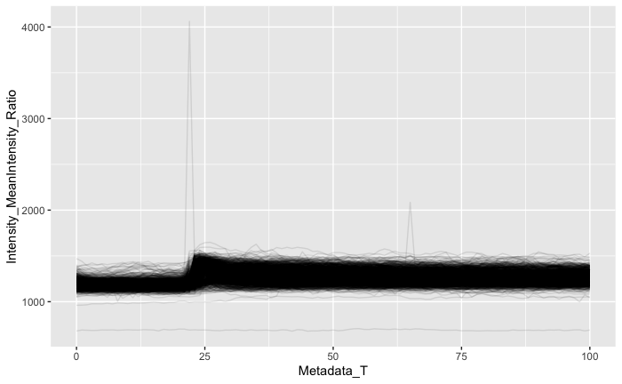

```r
p0 = ggplot(dtAll, aes_string(x = lCol$frame, y = lCol$meas, group = lCol$trackiduni)) +
  geom_path(alpha = 0.1) # parameter alpha adds transparency

p0
```

…and we have outliers. Actually, two kinds of outliers. Some time series have single time points that are way above the average. There are also several time series that are behaving entirely differently to the rest, so called *dynamic outliers*.

## Point outliers

Let’s remove single time points above the threshold **2000**, and impute them with interpolated data.

| Stim_Treat | Metadata_T | Intensity_MeanIntensity_Ratio | Stim_Conc | TrackObjects_Label_Uni |
| --- | --- | --- | --- | --- |
| EGF | 22 | 4060.864 | 250 ng/ml | EGF_00_0022 |
| FGF | 65 | 2085.110 | 25 ng/ml | FGF_05_0018 |

```r
# replace time points with measurements above the threshold with NA's
dtAll[get(lCol$meas) > 2000, (lCol$meas) := NA]

# interpolate NA's (again)
dtAll[, (lCol$meas) := na_interpolation(get(lCol$meas)), by = c(lCol$trackiduni)]
```

## Dynamic outliers

Let’s remove entire trajectories if the measurment is below **1000**:

```r
# vector with unique track id's of dynamic outliers
vsTrackOut = unique(dtAll[get(lCol$meas) < 1000][[lCol$trackiduni]])

# leave only tracks that are not in th eoutlier vector
dtAll = dtAll[!(get(lCol$trackiduni) %in% vsTrackOut)]
```

# Milestone 3

Let’s save the resulting data as a milestone for future reference:

```r
sFilePathTmp = file.path(lPar$dirRoot, lPar$dirData, "m3_allGF_wExpDescr_noNAs_noOut.csv")

fwrite(x = dtAll, file = sFilePathTmp, row.names = F)

# Compress the file to save space
gzip(sFilePathTmp, overwrite = T)

rm(sFilePathTmp)
```

If your are completely lost, here’s a file with the dataset resulting from previous steps:

```r
dtAll = fread(file.path(lPar$dirRoot, lPar$dirData, "m3_allGF_wExpDescr_noNAs_noOut.csv"))
```

# Plotting (coninued)

## Plot per condition

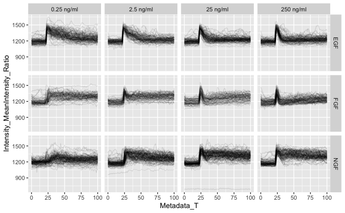

```r
p1 = p0 +
  facet_grid(Stim_Treat ~ Stim_Conc)

# The facet_grid accepts a formula with column names; the equivalent to use vasriables with column names is:
# facet_grid(as.formula(paste0(lCol$treatGF, "~", lCol$treatConc)))

p1
```

## Adding stats

### The mean

```r
p2 = p1 +
  stat_summary(
      aes_string(y = lCol$meas, group = 1),
      fun.y = mean,
      colour = 'red',
      linetype = 'solid',
      size = 1,
      geom = "line",
      group = 1
    )

p2
```

[output not shown]

### Confidence intervals

```r
p3 = p2 +
    stat_summary(
      aes_string(y = lCol$meas, group = 1),
      fun.data = mean_cl_normal,
      colour = 'red',
      alpha = 0.25,
      geom = "ribbon",
      group = 1,
      linetype = "dashed"
    )
p3
```

[output not shown]

## Interactive plots

For the sake of clarity, we choose only one condition for plotting:

```r
pInt = ggplot(dtAll[get(lCol$treatGF) == "NGF" & get(lCol$treatConc) == "0.25 ng/ml"],
              aes_string(x = lCol$frame,
                         y = lCol$meas,
                         group = lCol$trackiduni)) +
  geom_path(alpha = 0.1) +
  facet_grid(Stim_Treat ~ Stim_Conc)

ggplotly(pInt)
```

## Beautifying ggplots

Add themes, e.g. `+ theme_bw()`, or themes available in packages such as `ggthemes`.

Use `+ labels() to add the title, subtitle, the caption.

Use `+ xlab()` or `+ ylab()` to control labels of x and y axes.

```r
p3 +
  theme_minimal() +
  labs(title = "ERK activity in response to sustained GF treatments",
       caption = paste0("Created on ", Sys.Date())) +
  xlab("Time (min)") +
  ylab("ERK activity")
```

# Clustering

## Hierarchical clustering

We will use a standard R function `hclust` to perform hierarchical clustering. The first and only required argument of that function is a matrix with all pairwise distances between the time series. We obtain such a matrix with a `dist` function, which requires the data in a wide format. To convert from long to wide format we use `dcast` function.

### Convert from long to wide format

```r
# long to wide format
# every row corresponds to a single time series; column are time points
dtAllWide = dcast(dtAll, TrackObjects_Label_Uni ~ Metadata_T, value.var = "Intensity_MeanIntensity_Ratio")

# obtain row names for later
vsRowNames = dtAllWide[[lCol$trackiduni]]

# make a matrix
mAllWide = as.matrix(dtAllWide[, -1])

# assign row names to the matrix (useful for later plotting heatmaps from clustering)
rownames(mAllWide) = vsRowNames
```

### Distance matrix

```r
mDist = dist(mAllWide, method = "Euclidean")
```

[output not shown]

### hclust

```r
clRes = hclust(mDist, method = "complete")
str(clRes)
```

```
List of 7
 $ merge      : int [1:1186, 1:2] -93 -73 -159 -20 -195 -12 -416 -70 -490 -412 ...
 $ height     : num [1:1186] 114 121 125 127 133 ...
 $ order      : int [1:1187] 849 813 935 378 648 986 1022 1087 529 541 ...
 $ labels     : chr [1:1187] "EGF_00_0003" "EGF_00_0004" "EGF_00_0008" "EGF_00_0012" ...
 $ method     : chr "complete"
 $ call       : language hclust(d = mDist, method = "complete")
 $ dist.method: chr "euclidean"
 - attr(*, "class")= chr "hclust"
```

### Plot

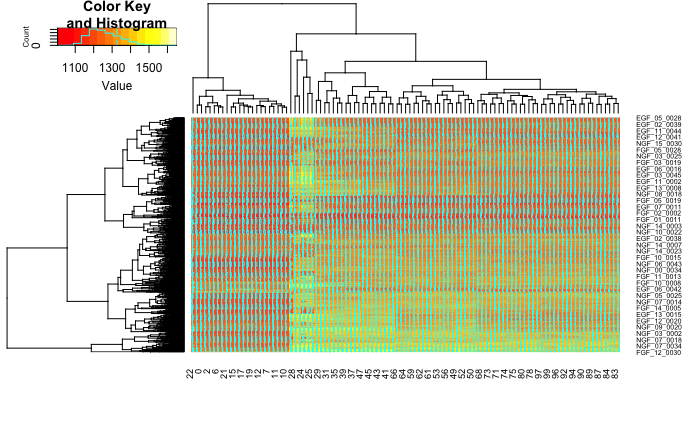

Remove unnecessary stuff: the dendrogram for columns

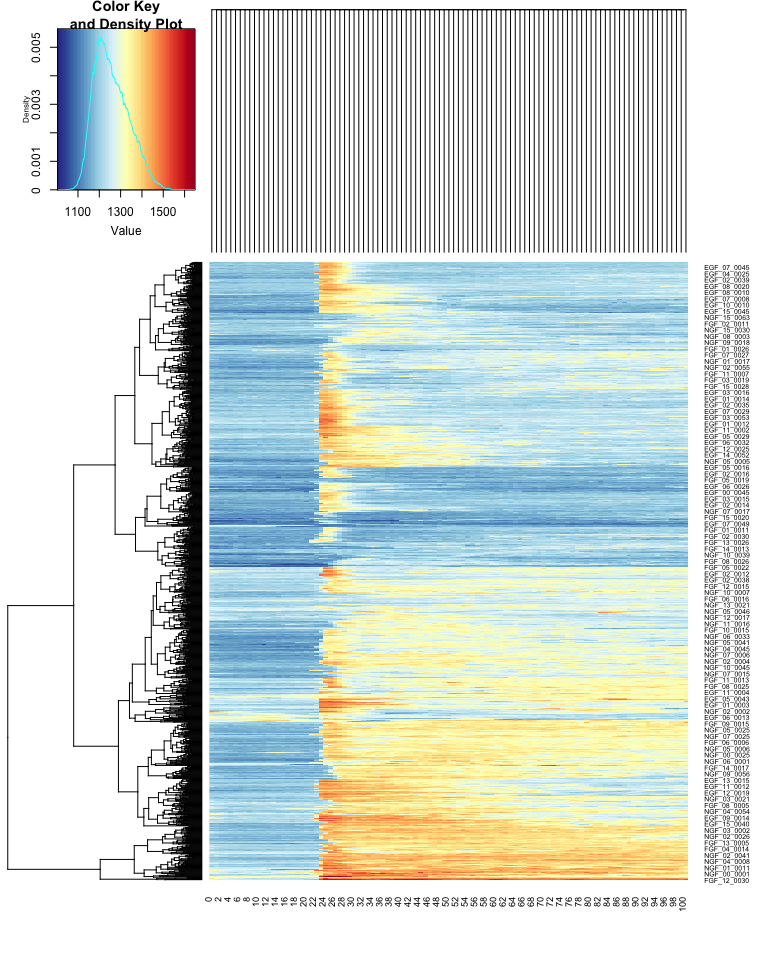

```r
heatmap.2(mAllWide,
          trace = "none",
          Colv = "Null",
          density.info = "density",
          col = rev(colorRampPalette(brewer.pal(11, "RdYlBu"))(99)))
```

## Interactive heatmaps

## K-means

## Measures of clustering quality

# Advanced topics

## Command-line parameters